# *NBA Body Type Variation Oscillates Over Seasons: A Data Science Tutorial*

### CMSC320 Final Project

### By Ethan Cheng

**Clear communication is key in data science; in this tutorial, we will review the steps of the data science pipeline by using sports data to explore a recent trend in NBA basketball.**

Over the past few decades, the analytics revolution has slowly been seeping into all sports, thanks partially to the rise of stats-tracking systems. Armed with these insights, sports teams have begun to quietly transform all aspects of their business, from player scouting/development to tactics and strategies during actual gameplay.

Generally these trends and insights aren't communicated to the public as they are being used to gain a competitive advantage in the sport. However, this data can also be used by sport writers and data scientists as part of the wave of data journalism spearheaded by [Nate Silver's FiveThirtyEight](https://fivethirtyeight.com/). Other publications like [The Ringer](https://www.theringer.com/) also make heavy use of data in their content.

In this tutorial, we will analyze many decades of player data to find quantitative support for the anecdotes/observations detailed in an article written by Seerat Sohi for Yahoo Sports. In it, Sohi points to the increasing number of recently drafted "undersized bruisers" - players who are strong, but shorter in height. It is interesting to theorize whether this trend is a reaction to the NBA's previous fascination with tall, long, and thin players who are versatile on defense and offense. This over-emphasis may have opened up a niche for these "bruiser" type players - we will analyze how the body dimensions and characteristics of NBA players relates to their role (star, role, or bench player) and whether this relationship has transformed, or is oscillatory, over time. The focus on player roles is because many of the "bruiser"-type players interviewed in Sohi's article are considered "role players" rather than stars; they fulfill circumscribed roles for the team and tend to serve more as the "supporting cast" to the star player.

This topic is important not just from a player analytics and sports history standpoint (mentioned above), but also because these criteria determine which players get drafted and get to continue playing in the league. Our hypothesis, pending the exploratory data analysis step, is that a multitude of timing factors can determine whether players with certain body types are "in fashion" in the league, and this trend is predictable and able to be modeled.

*To summarize, if you are an interested in data and/or sports journalism, an NBA fan, or just an aspiring data scienctist, go through the tutorial below where we will explain how to leverage data science skills to explore this topic - and others like it! [Here is the repo with the source code notebook for this tutorial.](https://github.com/echeng6/DSTutorialNBA)*

```python
import pandas as pd
import matplotlib.pyplot as plt
import numpy as np
```

Throughout this tutorial, we will embed links to helpful data science resources where they are relevant.

First, you are going to want to import useful Python packages that will facilitate data analysis. [Pandas](https://pandas.pydata.org/docs/) allows use to perform table operations on non-homogenous data, while [NumPy](https://numpy.org/doc/) allows us to easily manipulate with numerical arrays. [Matplotlib](https://matplotlib.org/stable/contents.html) is a graphing library that will help us visualize our results.

# Data Collection

The first, initializing step of data science is to collect the data you wish to analyze. There are many methods of obtaining this data: it may be available to download in their entirety online, distributed across many files, behind a paywall, or in its native state (html) on the website, requiring you to manually "scrape" it from the site.

For users of Python, the requests, [beautifulSoup](https://www.crummy.com/software/BeautifulSoup/bs4/doc/) and [lxml](https://lxml.de/) libraries are helpful tools for making web-scraping more efficient.

The "already prepared" datasets can come in many potential forms: [JSON](https://realpython.com/python-json/), CSV, and XML, as well as in a [SQL database](https://realpython.com/python-sql-libraries/). Our [data comes from Kaggle in CSV format](https://www.kaggle.com/drgilermo/nba-players-stats?select=player_data.csv) (can be accessed with a free Kaggle account), making it slightly easier to import and use the dataset. But it common for this data collection step to require many processing steps: check out [this sample list of curated datasets](https://github.com/awesomedata/awesome-public-datasets) to not only see the variety of forms data can come in; the data you need can be distrbuted across files or be an entirely different kind of data ([see graph networks](https://graphql.org/learn/)). It is important to read the data documentation to know what data types and fields the dataset contains - this will dictate how you collect, organize, and analyze it. Since this is such a foundational step, if you aren't familiar with a niche data type that you need to analyze/organize, reading background documentation first is advisable. It is possible, but not always the case, that you are able to convert data into another preferred form - sometimes you have to, or its better to, work within the data format you are given. For example, if your desired data is distributed across SQL tables, using the `JOIN` keyword can be easier than joining the distributed data in other data formats. Often times the data comes zipped as well, so being able to extract desired data effectively is important.

As we will soon see, knowing more about the context of the dataset (e.g. how it was collected, what the data fields mean), whether that be from prior knowledge or extensive reading of the provided documentation/relevant background, makes all aspects of the data science pipeline easier.

There are two tables: a `player_data` table and a `Seasons_Stats` table. The `player_data` table has each player's individual characteristics, including `name`, `height`, `weight`, and `birth_date`. The `Seasons_Stats` table contains each player's performance statistics data for each season; each player will appear in the table once for each season they played in (we will refer to each row of this table as representing one "player-season"). We have downloaded the CSV files from Kaggle; let's load the two tables using pandas.read_csv() function and their respective file paths- and print their size and column names below.

```python
players_data = pd.read_csv("archive/player_data.csv", sep = ',')
players_data.head()
```

|  | name | year_start | year_end | position | height | weight | birth_date | college |
| --- | --- | --- | --- | --- | --- | --- | --- | --- |
| 0 | Alaa Abdelnaby | 1991 | 1995 | F-C | 6-10 | 240.0 | June 24, 1968 | Duke University |
| 1 | Zaid Abdul-Aziz | 1969 | 1978 | C-F | 6-9 | 235.0 | April 7, 1946 | Iowa State University |
| 2 | Kareem Abdul-Jabbar | 1970 | 1989 | C | 7-2 | 225.0 | April 16, 1947 | University of California, Los Angeles |
| 3 | Mahmoud Abdul-Rauf | 1991 | 2001 | G | 6-1 | 162.0 | March 9, 1969 | Louisiana State University |
| 4 | Tariq Abdul-Wahad | 1998 | 2003 | F | 6-6 | 223.0 | November 3, 1974 | San Jose State University |

```python
print("There are " + str(players_data.shape[0]) + " NBA players in this dataset, along with " + str(players_data.shape[1]) + \
             " columns, listed below: ")
print(list(players_data.columns))
```

```
There are 4550 NBA players in this dataset, along with 8 columns, listed below:
['name', 'year_start', 'year_end', 'position', 'height', 'weight', 'birth_date', 'college']
```

```python
seasons_stats_data = pd.read_csv("archive/Seasons_Stats.csv", sep = ',')
seasons_stats_data.head()
```

|  | Unnamed: 0 | Year | Player | Pos | Age | Tm | G | GS | MP | PER | ... | FT% | ORB | DRB | TRB | AST | STL | BLK | TOV | PF | PTS |
| --- | --- | --- | --- | --- | --- | --- | --- | --- | --- | --- | --- | --- | --- | --- | --- | --- | --- | --- | --- | --- | --- |
| 0 | 0 | 1950.0 | Curly Armstrong | G-F | 31.0 | FTW | 63.0 | NaN | NaN | NaN | ... | 0.705 | NaN | NaN | NaN | 176.0 | NaN | NaN | NaN | 217.0 | 458.0 |
| 1 | 1 | 1950.0 | Cliff Barker | SG | 29.0 | INO | 49.0 | NaN | NaN | NaN | ... | 0.708 | NaN | NaN | NaN | 109.0 | NaN | NaN | NaN | 99.0 | 279.0 |
| 2 | 2 | 1950.0 | Leo Barnhorst | SF | 25.0 | CHS | 67.0 | NaN | NaN | NaN | ... | 0.698 | NaN | NaN | NaN | 140.0 | NaN | NaN | NaN | 192.0 | 438.0 |
| 3 | 3 | 1950.0 | Ed Bartels | F | 24.0 | TOT | 15.0 | NaN | NaN | NaN | ... | 0.559 | NaN | NaN | NaN | 20.0 | NaN | NaN | NaN | 29.0 | 63.0 |
| 4 | 4 | 1950.0 | Ed Bartels | F | 24.0 | DNN | 13.0 | NaN | NaN | NaN | ... | 0.548 | NaN | NaN | NaN | 20.0 | NaN | NaN | NaN | 27.0 | 59.0 |

5 rows × 53 columns

```python
print("There are " + str(seasons_stats_data.shape[0]) + \
      " sets of performance statistics for a player during a given season in this dataset, along with " + \
      str(seasons_stats_data.shape[1]) + " columns, \n listed below: ")
print(list(seasons_stats_data.columns))
```

```
There are 24691 sets of performance statistics for a player during a given season in this dataset, along with 53 columns,
 listed below:
['Unnamed: 0', 'Year', 'Player', 'Pos', 'Age', 'Tm', 'G', 'GS', 'MP', 'PER', 'TS%', '3PAr', 'FTr', 'ORB%', 'DRB%', 'TRB%', 'AST%', 'STL%', 'BLK%', 'TOV%', 'USG%', 'blanl', 'OWS', 'DWS', 'WS', 'WS/48', 'blank2', 'OBPM', 'DBPM', 'BPM', 'VORP', 'FG', 'FGA', 'FG%', '3P', '3PA', '3P%', '2P', '2PA', '2P%'…
```

As the printed data tables above show, pandas has imported the data into a non-homogeneous table, with each column heading representing the data contained in that column.

## Data Management and Tidying

One of the most important steps in the data science pipeline is understanding the organization of the dataset you are analyzing, and thus also its limitations, before then cleaning/organizing it. [Missing data is common for every dataset](https://cmsc320.github.io/lecs/cmsc320_s2021_lec13.pdf). It can be missing for a variety of reasons; the canonical types are listed below and more information can be found [here](https://www.ncbi.nlm.nih.gov/books/NBK493614/):

- Missing Completely at Random (MCAR) - the reason the data is missing is entirely by chance and is not related to other observed data
- Missing at Random (MAR) - the reason(s) the data is missing can be modeled somehow by the collected data
- Missing Not at Random (MNAR)- the reason(s) the data is missing cannot be modeled, or is itself missing from the data

In each of these cases, the approach for dealing with the missing data is different. Some general approaches for dealing with missing data include [imputation (many types)](https://towardsdatascience.com/6-different-ways-to-compensate-for-missing-values-data-imputation-with-examples-6022d9ca0779), exclusion of missing data, and exploratory analysis of the missing data itself. [Pandas provides some implemented ways](http://pandas.pydata.org/pandas-docs/stable/missing_data.html) for interpolating (using similar data that is present to replace missing data) and dropping/removing data with any/a variable amount of missing values. There are also packages/modules like [missingno](https://www.geeksforgeeks.org/python-visualize-missing-values-nan-values-using-missingno-library/) that help with tidying and visualizing/analyzing missing data, respectively.

Importantly, having some background knowledge about the nature of the dataset can help provide context about both how missing data should be treated and how the data can be tidied. Sometimes broad, strict policies, like removing all rows with missing values, or replacing all missing values with the average of that column, can do more harm when they are blindly applied.

Below we demonstrate how our NBA dataset can be tidied and analyzed in the context of our data science goals. First we will print the number of missing values in each column for both of our tables.

```python
print(players_data.isnull().sum())
```

```
name            0
year_start      0
year_end        0
position        1
height          1
weight          6
birth_date     31
college       302
dtype: int64
```

In our `player_data` table, missing values are concentrated in the `college` and `birth_date` columns. This identifying information is not important to our final goal of understanding NBA body type trends. However the `weight` and `height` fields are vital and this table is the only source of height and weight data in the entire dataset (both tables). Since there are only 6 players with missing `weight` values, let's look at each individually.

```python
players_data[players_data['weight'].isna()] #access the players/rows with missing weight values
```

|  | name | year_start | year_end | position | height | weight | birth_date | college |
| --- | --- | --- | --- | --- | --- | --- | --- | --- |
| 2142 | George Karl | 1974 | 1978 | NaN | NaN | NaN | May 12, 1952 | University of North Carolina |
| 2360 | Dick Lee | 1968 | 1968 | F | 6-6 | NaN | NaN | University of Washington |
| 2783 | Murray Mitchell | 1950 | 1950 | C | 6-6 | NaN | March 19, 1923 | Sam Houston State University |
| 2973 | Paul Nolen | 1954 | 1954 | C | 6-10 | NaN | September 3, 1929 | Texas Tech University |
| 4279 | Ray Wertis | 1947 | 1948 | G | 5-11 | NaN | January 1, 1922 | St. John's University |
| 4472 | Bob Wood | 1950 | 1950 | G | 5-10 | NaN | October 7, 1921 | Northern Illinois University |

Here is where background knowledge of basketball becomes helpful; **the NBA is very a "top-heavy" league, meaning that a small, elite group of players account for a disproportionate amount of team success. Thus, dropping one of these "star" players will have a more major impact on our perfomance data and analyses of which NBA body types tend to be successful and stay in the league.** Dropping all players with missing data (college, birth_dates) with dropna() could be a dangerous/biasing option. Even though we would still have a sizable amount of remaining data, we do not want to unintentionally drop a key player for our potential stratified analyses.

Since none of these players made a significant impact on the league, we can safely drop them from our dataset.

```python
to_drop = players_data[players_data['weight'].isna()].index
tidy_players_data = players_data.drop(index = to_drop)
print("There are now " + str(tidy_players_data.shape[0]) + " players in the player_data table.")
print(tidy_players_data.isnull().sum()) # print the number of missing values in each table column again
```

```
There are now 4544 players in the player_data table.
name            0
year_start      0
year_end        0
position        0
height          0
weight          0
birth_date     30
college       302
dtype: int64
```

As desired, we now have no missing height or weight values for NBA players; this tidied table will now be called `tidy_players_data`. Let's repeat this analysis for the `Seasons_Stats` data table.

```python
print(seasons_stats_data.isnull().sum())
# sum the number of missing values (true boolean value) for each column of Seasons_Stats table
```

```
Unnamed: 0        0
Year             67
Player           67
Pos              67
Age              75
Tm               67
G                67
GS             6458
MP              553
PER             590
TS%             153
3PAr           5852
FTr             166
ORB%           3899
DRB%           3899
TRB%           3120
AST%           2136
STL%           3899
BLK%           3899
TOV%           5109
USG%           5051
blanl         24691
OWS             106
DWS             106
WS              106
WS/48           590
blank2        24691
OBPM           3894
DBPM           3894
BPM            3894
VORP           3894
FG               67
FGA              67
FG%             166
3P             5764
3PA            5764
3P%            9275
2P               67
2PA              67
2P%             195
eFG%            166
FT               67
FTA              67
FT%             925
ORB            3894
DRB            3894
TRB             379
AST              67
STL            3894
BLK            3894
TOV            5046
PF               67
PTS              67
dtype: int64
```

```python
seasons_stats_data.dropna()
```

|  | Unnamed: 0 | Year | Player | Pos | Age | Tm | G | GS | MP | PER | ... | FT% | ORB | DRB | TRB | AST | STL | BLK | TOV | PF | PTS |
| --- | --- | --- | --- | --- | --- | --- | --- | --- | --- | --- | --- | --- | --- | --- | --- | --- | --- | --- | --- | --- | --- |

0 rows × 53 columns

Here the situation is different; there are many columns and each is missing a different number of values, likely for various reasons. If we just try to unambiguously drop all rows with missing values, we lose all the data (above), so this option is out. Instead, let's try to focus on the columns we need by first plotting the number of missing values for each feature column. We will plot the missing value counts from now on to make comparisions/analysis easier.

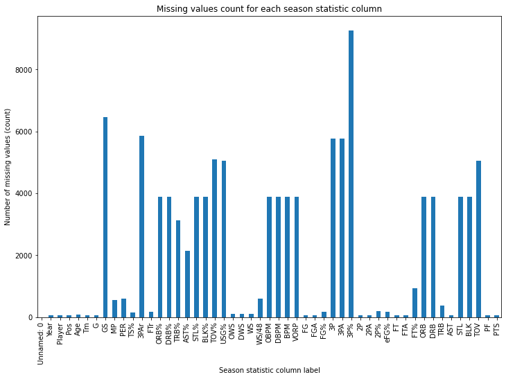

```python
seasons_stats_data.isnull().sum().drop('blanl').drop('blank2').plot.bar(figsize = (12, 8))
# two columns with 'blank' data were dropped

plt.title("Missing values count for each season statistic column")
plt.xlabel("Season statistic column label")
plt.ylabel("Number of missing values (count)")
plt.show()
```

```python
seasons_stats_data = seasons_stats_data.drop('blanl', axis = 'columns').drop('blank2', axis = 'columns')
# drop the blank columns we found
```

Again, sport history/context helps us here. It is known that most "canonical" performance statistics did not begin to be collected until a few decades after the league was established, and many new statistics have been added/tracked/recorded since then; a quick Google search would reveal exactly when, but to confirm, we will make our dataset tell us!

For example, the three point line was not established until many years after the league's founding as a way to give shorter, perimeter players more impact. The high frequency of missing three-pointer data (`3P`, `3PA`, `3P%` columns) in the bar plot above reflects this.

Most of the columns with many missing values will not end up being relevant for our analysis, so if a data scientist has a specific question and foresight, they can avoid having to tidy every corner of their dataset. **This acutally demonstrates the iterative nature of data science. Often times the needs of/results from future steps in the pipeline will prompt you revisit, reconsider, and/or redo past steps.** Since we do not know which exact features/columns we will need (and because this is a tutorial), let's try to tidy it up as much as we can.

To find the year stats tracking began for the NBA, lets count the fraction of missing values for each year. See the annotated code below.

```python
year_season_stats = [x for _, x in seasons_stats_data.groupby("Year")]
# group all the season_stats data by their year value
```

```python
years = pd.unique(seasons_stats_data['Year']).tolist()
del years[1]
# Create a useful ordered index/list of the years spanned by this dataset. This will be helpful for plotting.
# The deletion is for a nan value in the list.

print("The time range for this NBA statistics dataset is from " + str(int(min(years))) + "-" + str(int(max(years))) + ".")
print("This spans " + str(int(max(years) - min(years))) + " years.")
```

```
The time range for this NBA statistics dataset is from 1950-2017.
This spans 67 years.
```

Now let's count of the fraction of players for each year/season with a certain number missing values (above a certain threshold).

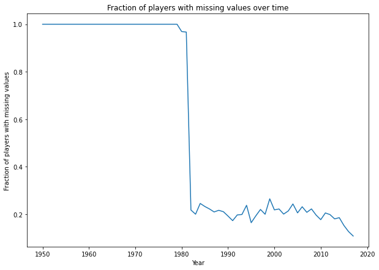

```python
plt.figure(figsize = (10, 7))
year_counts = []
thresh = 51
# this sets the number of non-missing values needed to define a row/player as non-missing in the missing fraction computed.
# Note that there are 51 columns, now that the blank ones have been dropped. The thres parameter can be changed as needed.

for i in range(len(year_season_stats)):
    frac_miss = year_season_stats[i].shape[0] - year_season_stats[i].dropna(axis = 0, thresh = thresh).shape[0]
    # this calculates the number of missing values that were dropped (difference in shape between pre-drop and
    # post-drop tables)
    year_counts.append(frac_miss/year_season_stats[i].shape[0]) # transform into a "fraction missing" value


plt.plot(years, year_counts)
plt.title('Fraction of players with missing values over time')
plt.ylabel("Fraction of players with missing values")
plt.xlabel("Year")
plt.show()
```

Our tenative data science question revolves around body types changing over the history of the NBA league, and whether a player's impact (role, bench, star player) may have an impact. While we have yet to fully define our analyses, or even do exploratory data analysis (we are still in data tidying stage), we can evaluate whether to drop data before 1981 by looking into statistics we anticipate using, and what seasons they tend to be missing for.

Two statistics we likely will use (besides height and weight) include games started (`GS`) and win shares (`WS`).

Starting games is directly correlated with being a high impact, star player, as opposed to a "supporting cast" player. Win shares is a statistic designed to estimate the number of team wins a player is responsible for; elite players tend to have large win shares values - later in the tutorial we will plot the distribution of win share values to provide more intuition for the measure. Its calculation is complex, incorporating many other performance statistics you are also able to split win shares between offensive and defensive impact; you can learn more here.

Below we find the most recent (maximum) year value among rows with missing `GS` and `WS` values.

```python
print("The most recent year for a row with a missing games started (GS) value is " + \
      str(int(max(pd.unique(seasons_stats_data[seasons_stats_data['GS'].isna()]['Year'])))) + ".")
print("The most recent year for a row with a missing win shares (WS) value is " + \
      str(int(max(pd.unique(seasons_stats_data[seasons_stats_data['WS'].isna()]['Year'][1:])))) + ".")
```

```
The most recent year for a row with a missing games started (GS) value is 1981.
The most recent year for a row with a missing win shares (WS) value is 1962.
```

Since two of the statistics we most care about only have missing values up to 1981, we can justify dropping the seasons_data before 1982. Let's see how that affects the rest of our dataset. We can plot the missing value counts for both before and after the dropping of these values.

```python
season_data_to_use = seasons_stats_data.loc[seasons_stats_data['Year'] > 1981]
```

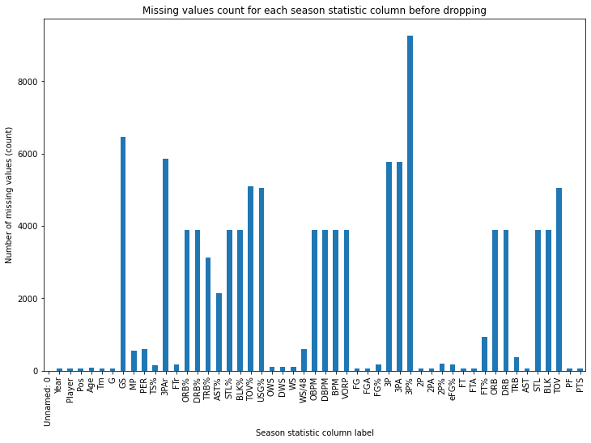

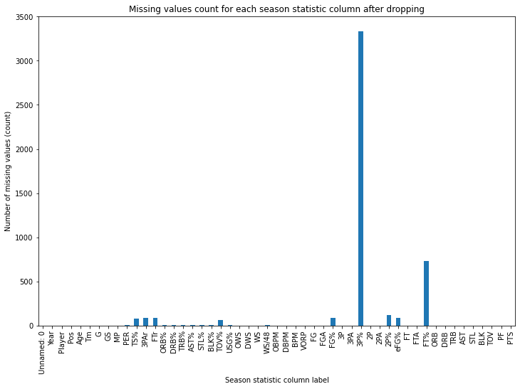

```python
seasons_stats_data.isnull().sum().plot.bar(figsize = (12, 8))
plt.title("Missing values count for each season statistic column before dropping")
plt.xlabel("Season statistic column label")
plt.ylabel("Number of missing values (count)")

plt.figure()
# after data pre-1982 was dropped, you will see, missing data goes down across the board
season_data_to_use.isnull().sum().plot.bar(figsize = (12, 8))

plt.title("Missing values count for each season statistic column after dropping")
plt.xlabel("Season statistic column label")
plt.ylabel("Number of missing values (count)")
plt.show()
```

Even though we are still missing some values, they are all rate statistics (`2P%` -two-point percentage, `3P%`, `PER`- player efficiency rating). We will not need them, and almost the same information can be retrieved from other non-rate statistics.

Now comes the difficult part; we need to combine the `player_data` and `season_data_to_use` tables so that the height and weight data is placed with its corresponding player for all the seasons they appear in. If the data were in SQL tables, we could use `JOIN`, which would be much easier.

While we haven't technically reached the exploratory data analysis (EDA) stage, we are creating the table that will be used in that stage. To prevent any mistakes from causing us to have to reprocess the table from scratch, let's make a copy. This is a good data science backup strategy when you plan to do something very experimental that may have unintended consquences.

```python
EDA_seasons_data = season_data_to_use.copy()
```

To do this, we iterate through all the rows of `EDA_seasons_data` and for each player's season, we will assign that player's height and weight from the `tidy_players_data` table to two new columns in `EDA_seasons_data`, `height` and `weight`. Each `height` and `weight` for a player will be entered X times where X is the number of seasons the player has played in the NBA (up until 2017). Annoyingly, some players' names have an asterisk at the end, so we will have to consider that case as well.

This approach also presumes that NBA players do not change their height or weight significantly throughout their career, which is a safe assumption in most cases. Even if it weren't, we do not have player data for how height and/or weight varies over time.

```python
for i in range(EDA_seasons_data.shape[0]):
    player_name = EDA_seasons_data.iloc[i]['Player'] # get the name of the player
    ind = EDA_seasons_data.index[i]  # index of the table for access since some indices have been removed
    if (player_name[-1] == '*'):
        if (tidy_players_data.loc[tidy_players_data['name'] == player_name[:-1]].shape[0] != 0):
            # If the player name matches without asterisk,
            EDA_seasons_data.loc[ind, 'height'] = tidy_players_data.loc[tidy_players_data['name'] == player_name[:-1]].iloc[0]['height']
            EDA_seasons_data.loc[ind, 'weight'] = tidy_players_data.loc[tidy_players_data['name'] == player_name[:-1]].iloc[0]['weight']
            # add matching height and weight
        else:
            EDA_seasons_data.loc[ind, 'height'] = pd.NA
            EDA_seasons_data.loc[ind, 'weight'] = pd.NA
            # otherwise, list as a missing value
    else:
        # Same as above, but without ending asterisk
        if (tidy_players_data.loc[tidy_players_data['name'] == player_name].shape[0] != 0):
            EDA_seasons_data.loc[ind, 'height'] = tidy_players_data.loc[tidy_players_data['name'] == player_name].iloc[0]['height']
            EDA_seasons_data.loc[ind, 'weight'] = tidy_players_data.loc[tidy_players_data['name'] == player_name].iloc[0]['weight']
        else:
            EDA_seasons_data.loc[ind, 'height'] = pd.NA
            EDA_seasons_data.loc[ind, 'weight'] = pd.NA
```

```python
EDA_seasons_data.head()
```

|  | Unnamed: 0 | Year | Player | Pos | Age | Tm | G | GS | MP | PER | ... | DRB | TRB | AST | STL | BLK | TOV | PF | PTS | height | weight |
| --- | --- | --- | --- | --- | --- | --- | --- | --- | --- | --- | --- | --- | --- | --- | --- | --- | --- | --- | --- | --- | --- |
| 6449 | 6449 | 1982.0 | Kareem Abdul-Jabbar* | C | 34.0 | LAL | 76.0 | 76.0 | 2677.0 | 23.4 | ... | 487.0 | 659.0 | 225.0 | 63.0 | 207.0 | 230.0 | 224.0 | 1818.0 | 7-2 | 225 |
| 6450 | 6450 | 1982.0 | Alvan Adams | C | 27.0 | PHO | 79.0 | 75.0 | 2393.0 | 18.6 | ... | 448.0 | 586.0 | 356.0 | 114.0 | 78.0 | 196.0 | 269.0 | 1196.0 | 6-9 | 210 |
| 6451 | 6451 | 1982.0 | Mark Aguirre | SF | 22.0 | DAL | 51.0 | 20.0 | 1468.0 | 17.3 | ... | 160.0 | 249.0 | 164.0 | 37.0 | 22.0 | 135.0 | 152.0 | 955.0 | 6-6 | 232 |
| 6452 | 6452 | 1982.0 | Danny Ainge | SG | 22.0 | BOS | 53.0 | 1.0 | 564.0 | 10.1 | ... | 31.0 | 56.0 | 87.0 | 37.0 | 3.0 | 53.0 | 86.0 | 219.0 | 6-4 | 175 |
| 6453 | 6453 | 1982.0 | Tiny Archibald* | PG | 33.0 | BOS | 68.0 | 51.0 | 2167.0 | 14.3 | ... | 91.0 | 116.0 | 541.0 | 52.0 | 3.0 | 178.0 | 131.0 | 858.0 | 6-1 | 150 |

5 rows × 53 columns

```python
print("This table has " + str(EDA_seasons_data.shape[0]) + " rows (player-seasons).")
```

```
This table has 18207 rows (player-seasons).
```

```python
EDA_seasons_data[EDA_seasons_data['Player'] == 'Nikola Jokic']
```

|  | Unnamed: 0 | Year | Player | Pos | Age | Tm | G | GS | MP | PER | ... | DRB | TRB | AST | STL | BLK | TOV | PF | PTS | height | weight |
| --- | --- | --- | --- | --- | --- | --- | --- | --- | --- | --- | --- | --- | --- | --- | --- | --- | --- | --- | --- | --- | --- |
| 23804 | 23804 | 2016.0 | Nikola Jokic | C | 20.0 | DEN | 80.0 | 55.0 | 1733.0 | 21.5 | ... | 379.0 | 560.0 | 189.0 | 79.0 | 50.0 | 104.0 | 208.0 | 796.0 | 6-10 | 250 |
| 24380 | 24380 | 2017.0 | Nikola Jokic | C | 21.0 | DEN | 73.0 | 59.0 | 2038.0 | 26.4 | ... | 506.0 | 718.0 | 359.0 | 61.0 | 56.0 | 171.0 | 214.0 | 1221.0 | 6-10 | 250 |

2 rows × 53 columns

```python
EDA_seasons_data[EDA_seasons_data['Player'] == 'Tim Duncan']
```

|  | Unnamed: 0 | Year | Player | Pos | Age | Tm | G | GS | MP | PER | ... | DRB | TRB | AST | STL | BLK | TOV | PF | PTS | height | weight |
| --- | --- | --- | --- | --- | --- | --- | --- | --- | --- | --- | --- | --- | --- | --- | --- | --- | --- | --- | --- | --- | --- |
| 13551 | 13551 | 1998.0 | Tim Duncan | PF | 21.0 | SAS | 82.0 | 82.0 | 3204.0 | 22.6 | ... | 703.0 | 977.0 | 224.0 | 55.0 | 206.0 | 279.0 | 254.0 | 1731.0 | 6-11 | 250 |
| 14096 | 14096 | 1999.0 | Tim Duncan | PF | 22.0 | SAS | 50.0 | 50.0 | 1963.0 | 23.2 | ... | 412.0 | 571.0 | 121.0 | 45.0 | 126.0 | 146.0 | 147.0 | 1084.0 | 6-11 | 250 |
| 14607 | 14607 | 2000.0 | Tim Duncan | PF | 23.0 | SAS | 74.0 | 74.0 | 2875.0 | 24.8 | ... | 656.0 | 918.0 | 234.0 | 66.0 | 165.0 | 242.0 | 210.0 | 1716.0 | 6-11 | 250 |
| 15103 | 15103 | 2001.0 | Tim Duncan | PF | 24.0 | SAS | 82.0 | 82.0 | 3174.0 | 23.8 | ... | 738.0 | 997.0 | 245.0 | 70.0 | 192.0 | 242.0 | 247.0 | 1820.0 | 6-11 | 250 |
| 15643 | 15643 | 2002.0 | Tim Duncan | PF | 25.0 | SAS | 82.0 | 82.0 | 3329.0 | 27.0 | ... | 774.0 | 1042.0 | 307.0 | 61.0 | 203.0 | 263.0 | 217.0 | 2089.0 | 6-11 | 250 |
| 16129 | 16129 | 2003.0 | Tim Duncan | PF | 26.0 | SAS | 81.0 | 81.0 | 3181.0 | 26.9 | ... | 784.0 | 1043.0 | 316.0 | 55.0 | 237.0 | 248.0 | 231.0 | 1884.0 | 6-11 | 250 |
| 16647 | 16647 | 2004.0 | Tim Duncan | PF | 27.0 | SAS | 69.0 | 68.0 | 2527.0 | 27.1 | ... | 632.0 | 859.0 | 213.0 | 62.0 | 185.0 | 183.0 | 164.0 | 1538.0 | 6-11 | 250 |
| 17234 | 17234 | 2005.0 | Tim Duncan | PF | 28.0 | SAS | 66.0 | 66.0 | 2203.0 | 27.0 | ... | 530.0 | 732.0 | 179.0 | 45.0 | 174.0 | 127.0 | 144.0 | 1342.0 | 6-11 | 250 |
| 17806 | 17806 | 2006.0 | Tim Duncan | PF | 29.0 | SAS | 80.0 | 80.0 | 2784.0 | 23.1 | ... | 650.0 | 881.0 | 253.0 | 70.0 | 162.0 | 198.0 | 219.0 | 1485.0 | 6-11 | 250 |
| 18351 | 18351 | 2007.0 | Tim Duncan | C | 30.0 | SAS | 80.0 | 80.0 | 2726.0 | 26.1 | ... | 633.0 | 846.0 | 273.0 | 66.0 | 190.0 | 224.0 | 203.0 | 1599.0 | 6-11 | 250 |
| 18889 | 18889 | 2008.0 | Tim Duncan | C | 31.0 | SAS | 78.0 | 78.0 | 2651.0 | 24.4 | ... | 644.0 | 881.0 | 218.0 | 56.0 | 152.0 | 178.0 | 185.0 | 1508.0 | 6-11 | 250 |
| 19504 | 19504 | 2009.0 | Tim Duncan | C | 32.0 | SAS | 75.0 | 75.0 | 2524.0 | 24.4 | ... | 599.0 | 800.0 | 264.0 | 38.0 | 126.0 | 165.0 | 173.0 | 1450.0 | 6-11 | 250 |
| 20069 | 20069 | 2010.0 | Tim Duncan | C | 33.0 | SAS | 78.0 | 77.0 | 2438.0 | 24.7 | ... | 567.0 | 788.0 | 246.0 | 45.0 | 117.0 | 140.0 | 152.0 | 1395.0 | 6-11 | 250 |
| 20681 | 20681 | 2011.0 | Tim Duncan | C | 34.0 | SAS | 76.0 | 76.0 | 2156.0 | 21.9 | ... | 509.0 | 678.0 | 203.0 | 50.0 | 146.0 | 122.0 | 119.0 | 1022.0 | 6-11 | 250 |
| 21262 | 21262 | 2012.0 | Tim Duncan | C | 35.0 | SAS | 58.0 | 58.0 | 1634.0 | 22.5 | ... | 410.0 | 520.0 | 132.0 | 38.0 | 88.0 | 97.0 | 98.0 | 895.0 | 6-11 | 250 |
| 21825 | 21825 | 2013.0 | Tim Duncan | C | 36.0 | SAS | 69.0 | 69.0 | 2078.0 | 24.4 | ... | 562.0 | 686.0 | 184.0 | 50.0 | 183.0 | 147.0 | 117.0 | 1227.0 | 6-11 | 250 |
| 22436 | 22436 | 2014.0 | Tim Duncan | C | 37.0 | SAS | 74.0 | 74.0 | 2158.0 | 21.3 | ... | 563.0 | 721.0 | 220.0 | 43.0 | 139.0 | 159.0 | 134.0 | 1119.0 | 6-11 | 250 |
| 23038 | 23038 | 2015.0 | Tim Duncan | C | 38.0 | SAS | 77.0 | 77.0 | 2227.0 | 22.6 | ... | 534.0 | 704.0 | 230.0 | 63.0 | 151.0 | 131.0 | 165.0 | 1070.0 | 6-11 | 250 |
| 23652 | 23652 | 2016.0 | Tim Duncan | C | 39.0 | SAS | 61.0 | 60.0 | 1536.0 | 16.9 | ... | 332.0 | 447.0 | 163.0 | 47.0 | 78.0 | 90.0 | 125.0 | 522.0 | 6-11 | 250 |

19 rows × 53 columns

As we can see above, the `height` and `weight` values transferred effectively. We also displayed all the rows for two players: Nikola Jokic (the presumptive 2020-21 MVP) and Tim Duncan to show that the same height and weight are listed for all that player's rows (representing all the seasons they played up until 2017). However, not all weights and heights were transferred, as some entries are missing in the combined table (below).

```python
print("There are " + str(int(EDA_seasons_data['weight'].isna().sum())) + " missing weight values.")
print("There are " + str(int(EDA_seasons_data['height'].isna().sum())) + " missing height values.")
```

```
There are 145 missing weight values.
There are 145 missing height values.
```

When we take a closer look at the values that are missing, we notice that it is due to the fact that the players' names do not match between tables. The `tidy_player_data` table has the players full name, while the `seasons_stats_data`/`EDA_seasons_data` tables cuts off players names that have more than two words. An example is shown for the player called, "Metta World Peace". In the `seasons_stats_data`/`EDA_seasons_data` tabled his name is only listed as "Metta World".

```python
EDA_seasons_data[EDA_seasons_data['weight'].isna()]
```

|  | Unnamed: 0 | Year | Player | Pos | Age | Tm | G | GS | MP | PER | ... | DRB | TRB | AST | STL | BLK | TOV | PF | PTS | height | weight |
| --- | --- | --- | --- | --- | --- | --- | --- | --- | --- | --- | --- | --- | --- | --- | --- | --- | --- | --- | --- | --- | --- |
| 6464 | 6464 | 1982.0 | Billy Ray | SG | 25.0 | POR | 75.0 | 0.0 | 1229.0 | 17.8 | ... | 55.0 | 108.0 | 111.0 | 41.0 | 5.0 | 93.0 | 100.0 | 832.0 | <NA> | <NA> |
| 6497 | 6497 | 1982.0 | Joe Barry | C | 23.0 | GSW | 76.0 | 75.0 | 2627.0 | 15.9 | ... | 423.0 | 633.0 | 64.0 | 64.0 | 127.0 | 206.0 | 265.0 | 1289.0 | <NA> | <NA> |
| 6554 | 6554 | 1982.0 | World B. | SG | 28.0 | GSW | 78.0 | 78.0 | 2796.0 | 18.2 | ... | 130.0 | 248.0 | 419.0 | 71.0 | 8.0 | 208.0 | 222.0 | 1789.0 | <NA> | <NA> |
| 6729 | 6729 | 1982.0 | Micheal Ray | PG | 26.0 | NYK | 82.0 | 79.0 | 3044.0 | 17.7 | ... | 388.0 | 565.0 | 572.0 | 213.0 | 41.0 | 291.0 | 317.0 | 1469.0 | <NA> | <NA> |
| 6780 | 6780 | 1982.0 | Jan Van | SF | 30.0 | NJN | 41.0 | 0.0 | 452.0 | 10.2 | ... | 31.0 | 48.0 | 32.0 | 12.0 | 13.0 | 29.0 | 63.0 | 144.0 | <NA> | <NA> |
| ... | ... | ... | ... | ... | ... | ... | ... | ... | ... | ... | ... | ... | ... | ... | ... | ... | ... | ... | ... | ... | ... |
| 24085 | 24085 | 2016.0 | Metta World | SF | 36.0 | LAL | 35.0 | 5.0 | 590.0 | 8.3 | ... | 70.0 | 89.0 | 27.0 | 22.0 | 11.0 | 15.0 | 67.0 | 176.0 | <NA> | <NA> |
| 24439 | 24439 | 2017.0 | Luc Mbah | SF | 30.0 | LAC | 80.0 | 76.0 | 1787.0 | 10.3 | ... | 127.0 | 174.0 | 39.0 | 81.0 | 35.0 | 47.0 | 122.0 | 484.0 | <NA> | <NA> |
| 24440 | 24440 | 2017.0 | James Michael | PF | 24.0 | GSW | 52.0 | 2.0 | 457.0 | 13.0 | ... | 56.0 | 90.0 | 17.0 | 18.0 | 29.0 | 19.0 | 47.0 | 147.0 | <NA> | <NA> |
| 24442 | 24442 | 2017.0 | Sheldon McClellan | SG | 24.0 | WAS | 30.0 | 3.0 | 287.0 | 10.1 | ... | 30.0 | 34.0 | 15.0 | 8.0 | 2.0 | 5.0 | 17.0 | 90.0 | <NA> | <NA> |
| 24679 | 24679 | 2017.0 | Metta World | SF | 37.0 | LAL | 25.0 | 2.0 | 160.0 | 6.2 | ... | 15.0 | 20.0 | 11.0 | 9.0 | 2.0 | 7.0 | 18.0 | 57.0 | <NA> | <NA> |

145 rows × 53 columns

```python
tidy_players_data[tidy_players_data['name'] == 'Metta World Peace']
```

|  | name | year_start | year_end | position | height | weight | birth_date | college |
| --- | --- | --- | --- | --- | --- | --- | --- | --- |
| 4487 | Metta World Peace | 2000 | 2017 | F | 6-6 | 260.0 | November 13, 1979 | St. John's University |

This is difficult to fix as we would have to iterate through all players with long names and missing height/weight data and fix their real name listing to transfer the height and weight data - there is no way around checking and searching for each complete name.

To avoid having to doing this, we can justify their removal as only 145 player-seasons would be dropped from a table with 18207 player-seasons. Below we have plotted the win-shares (`WS`) and year distribution of both player-seasons we would be dropping and player-sesons that will be kept. These distributions are similar enough, and the magnitude of dropped players low enough, that we can justify their exclusion for this tutorial/analyses as unbiasing.

In the plots below, we just use `weight` to find the right rows, as `height` values are missing from the same exact rows.

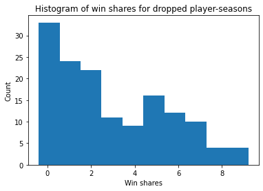

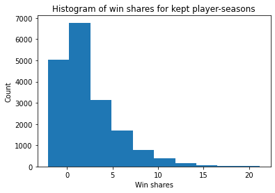

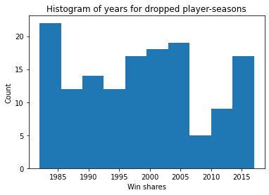

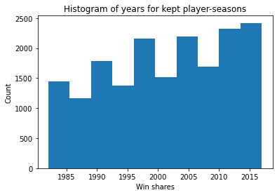

```python
_ = plt.hist(EDA_seasons_data[EDA_seasons_data['weight'].isna()]['WS']) # win share values for dropped rows
plt.title("Histogram of win shares for dropped player-seasons")
plt.xlabel("Win shares")
plt.ylabel("Count")

plt.figure()
_ = plt.hist(EDA_seasons_data[EDA_seasons_data['weight'].notna()]['WS']) # win share values for non-dropped rows
plt.title("Histogram of win shares for kept player-seasons")
plt.xlabel("Win shares")
plt.ylabel("Count")

plt.figure()
_ = plt.hist(EDA_seasons_data[EDA_seasons_data['weight'].isna()]['Year']) # year values for dropped rows
plt.title("Histogram of years for dropped player-seasons")
plt.xlabel("Win shares")
plt.ylabel("Count")

plt.figure()
_ = plt.hist(EDA_seasons_data[EDA_seasons_data['weight'].notna()]['Year']) # year values for dropped rows
plt.title("Histogram of years for kept player-seasons")
plt.xlabel("Win shares")
plt.ylabel("Count")

plt.show()
```

```python
drop_inds = EDA_seasons_data.index[EDA_seasons_data['weight'].isna()]
EDA_seasons_data = EDA_seasons_data.drop(index = drop_inds)
print("Now there are " + str(int(EDA_seasons_data['weight'].isna().sum())) + " missing weight values.")
print("Now there are " + str(int(EDA_seasons_data['height'].isna().sum())) + " missing height values.")
```

```
Now there are 0 missing weight values.
Now there are 0 missing height values.
```

Even though we are still missing some values, they are again all rate statistics (e.g. `2P%` - two-point percentage, `3P%`- three-point percentage, `PER`- player efficiency rating). We will not need them, and almost the same information can be retrieved from other non-rate statistics. So, onto EDA!

## Exploratory Data Analysis

Now that our data is tidied and missing values dealt with, we can begin exploratory data analyses (EDA). EDA is a step in the pipeline dedicated to surveying any interesting trends in the dataset, without necessarily having a clear hypothesis/analysis in mind yet. Our `EDA_seasons_data` table has a ton of data to parse through, but luckily we already have a rough question we are seeking to answer. We can direct our exploratory analyses this way, and streamline it.

If we have a dataset, but no clear question or focus, unsupervised learning, e.g. using [principal component analysis](https://towardsdatascience.com/pca-using-python-scikit-learn-e653f8989e60) or k-means clustering , can be one option for finding trends in the data. We can also generate a [covariance matrix](https://machinelearningmastery.com/introduction-to-expected-value-variance-and-covariance/) for some of the numerical data in our tidied dataset using NumPy to look for candidate correlations to examine further. For this tutorial, we will focus on the correlation we care about, body type over time, and the factors that modulate it. This is a bit more focused than "true" exploratory data analyses, but it is still preliminary as we are not testing any hypotheses yet, just surveying the statistics we have.

To get a wholelistic measure of "body type" we will combine `weight` and `height` into [body mass index](https://www.cdc.gov/nccdphp/dnpao/growthcharts/training/bmiage/page5_2.html#:~:text=Then%2C%20calculate%20BMI%20by%20dividing,round%20to%20one%20decimal%20place) (BMI), which characterizes one's body weight relative to their body size, and see how the BMI of players varies across years/seasons. As a reminder, the body types mentioned in the article that inspired this tutorial's topic include the short, strong, and bulky bruisers (expect larger BMI), and taller, lanky players with long wingspans (expect smaller BMI). Of course, this is the NBA, so "short" and "tall" are relative to the average for the league.

First, we should convert height from "feet-inches" format to total inches (`height_inches`) by parsing the height string, and using that field, along with `weight` (pounds), to compute the BMI. The [formula](https://www.cdc.gov/nccdphp/dnpao/growthcharts/training/bmiage/page5_2.html#:~:text=Then%2C%20calculate%20BMI%20by%20dividing,round%20to%20one%20decimal%20place.) for BMI with height (inches) and weight (pounds) is listed below:

*BMI = (weight/(height x height)) x 703*

```python
for i in range(EDA_seasons_data.shape[0]):
    height = EDA_seasons_data.iloc[i]['height']
    ind = EDA_seasons_data.index[i]

    height_inches = 12 * int(height[0]) + int(height[2])
    # compute height in total inches from "feet-inches" string format with string parsing
    EDA_seasons_data.loc[ind, 'height_inches'] = height_inches

for i in range(EDA_seasons_data.shape[0]):
    # go back through and collect total height and weight values in inches and pounds
    height = EDA_seasons_data.iloc[i]['height_inches']
    weight = EDA_seasons_data.iloc[i]['weight']
    ind = EDA_seasons_data.index[i]

    # and compute BMI using the given formula
    EDA_seasons_data.loc[ind, 'BMI'] = (weight/(height**2)) * 703
```

```python
EDA_seasons_data.head()
```

|  | Unnamed: 0 | Year | Player | Pos | Age | Tm | G | GS | MP | PER | ... | AST | STL | BLK | TOV | PF | PTS | height | weight | height_inches | BMI |
| --- | --- | --- | --- | --- | --- | --- | --- | --- | --- | --- | --- | --- | --- | --- | --- | --- | --- | --- | --- | --- | --- |
| 6449 | 6449 | 1982.0 | Kareem Abdul-Jabbar* | C | 34.0 | LAL | 76.0 | 76.0 | 2677.0 | 23.4 | ... | 225.0 | 63.0 | 207.0 | 230.0 | 224.0 | 1818.0 | 7-2 | 225 | 86.0 | 21.386560 |
| 6450 | 6450 | 1982.0 | Alvan Adams | C | 27.0 | PHO | 79.0 | 75.0 | 2393.0 | 18.6 | ... | 356.0 | 114.0 | 78.0 | 196.0 | 269.0 | 1196.0 | 6-9 | 210 | 81.0 | 22.501143 |
| 6451 | 6451 | 1982.0 | Mark Aguirre | SF | 22.0 | DAL | 51.0 | 20.0 | 1468.0 | 17.3 | ... | 164.0 | 37.0 | 22.0 | 135.0 | 152.0 | 955.0 | 6-6 | 232 | 78.0 | 26.807364 |
| 6452 | 6452 | 1982.0 | Danny Ainge | SG | 22.0 | BOS | 53.0 | 1.0 | 564.0 | 10.1 | ... | 87.0 | 37.0 | 3.0 | 53.0 | 86.0 | 219.0 | 6-4 | 175 | 76.0 | 21.299342 |
| 6453 | 6453 | 1982.0 | Tiny Archibald* | PG | 33.0 | BOS | 68.0 | 51.0 | 2167.0 | 14.3 | ... | 541.0 | 52.0 | 3.0 | 178.0 | 131.0 | 858.0 | 6-1 | 150 | 73.0 | 19.787953 |

5 rows × 55 columns

Now let's plot the mean and standard deviation of weight, height, and BMI over the seasons/time.

```python
EDA_season_stats = [x for _, x in EDA_seasons_data.groupby("Year")] # split data into groups by year
```

```python
years = pd.unique(EDA_seasons_data['Year']) # get year values to use as x axis

# calculate the mean and standard deviation of BMI for each season using a list comprehension
# we will only annotate the weight analyses as the rest of the cell repeat this for other statistics
mean_weights_yr = [EDA_season_stats[i]['weight'].mean() for i in range(len(EDA_season_stats))]
std_weights_yr = [EDA_season_stats[i]['weight'].std() for i in range(len(EDA_season_stats))]
```

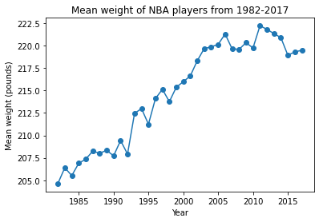

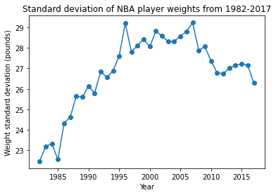

```python
plt.title("Mean weight of NBA players from 1982-2017")
plt.xlabel("Year")
plt.ylabel("Mean weight (pounds)")
plt.plot(years, mean_weights_yr)
plt.scatter(years, mean_weights_yr)

plt.figure()
plt.title("Standard deviation of NBA player weights from 1982-2017")
plt.xlabel("Year")
plt.ylabel("Weight standard deviation (pounds)")
plt.plot(years, std_weights_yr)
plt.scatter(years, std_weights_yr)

plt.show()
```

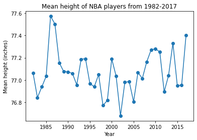

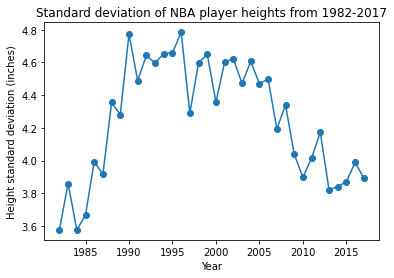

```python
years = pd.unique(EDA_seasons_data['Year'])
mean_heights_yr = [EDA_season_stats[i]['height_inches'].mean() for i in range(len(EDA_season_stats))]
std_heights_yr = [EDA_season_stats[i]['height_inches'].std() for i in range(len(EDA_season_stats))]

plt.title("Mean height of NBA players from 1982-2017")
plt.xlabel("Year")
plt.ylabel("Mean height (inches)")
plt.plot(years, mean_heights_yr)
plt.scatter(years, mean_heights_yr)

plt.figure()
plt.title("Standard deviation of NBA player heights from 1982-2017")
plt.xlabel("Year")
plt.ylabel("Height standard deviation (inches)")
plt.plot(years, std_heights_yr)
plt.scatter(years, std_heights_yr)

plt.show()
```

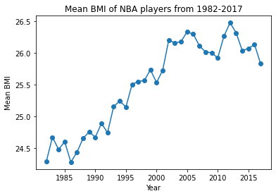

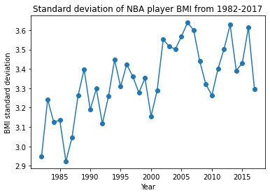

```python
years = pd.unique(EDA_seasons_data['Year'])
mean_BMI_yr = [EDA_season_stats[i]['BMI'].mean() for i in range(len(EDA_season_stats))]
std_BMI_yr = [EDA_season_stats[i]['BMI'].std() for i in range(len(EDA_season_stats))]

plt.title("Mean BMI of NBA players from 1982-2017")
plt.xlabel("Year")
plt.ylabel("Mean BMI")
plt.plot(years, mean_BMI_yr)
plt.scatter(years, mean_BMI_yr)

plt.figure()
plt.title("Standard deviation of NBA player BMI from 1982-2017")
plt.xlabel("Year")
plt.ylabel("BMI standard deviation")
plt.plot(years, std_BMI_yr)
plt.scatter(years, std_BMI_yr)


plt.show()

plt.show()
```

Our exploratory analysis show some interesting trends for weight, height, and BMI.

Both mean weight and weight standard deviation seem to oscillate less over time than height. Weight has been steadily growing as NBA players have become more fit, strong, and lean over time with better and better training methods and technology. Height meanwhile seems more capped, and has always varied within the 76-78 inch range. However, the standard deviation of player heights in the league has oscillated up and down practically every year, growing in variability and peaking in the 1990s, before slowly becoming more homogeneous and less variable in recent years.

We can interpret the data like this: the large drops in standard deviation represent "homogenization events" where the types of bodies in the NBA tend to be more alike. This is a common occurence - NBA teams and front offices tend to copy each other's good ideas, whether they be about the [draft/team building](https://www.theringer.com/nba/2021/3/17/22335035/nba-trade-deadline-first-pick-protection), or [play on the court](https://fivethirtyeight.com/features/the-bucks-built-the-nbas-best-defense-now-other-teams-are-copying-it/). It's fascinating that years that would qualify as "homogenization events" are quickly and consistently followed by years of increasing "body type diversity", measured by higher BMI standard deviations. We could interpret this as saying that a more homogeneous league is more susceptible to "invasion" by diverse body typesthat fulfill niche roles in the league.

If you look closely, you'll even notice that within these larger periods there are consistent oscillations of about 3-4 seasons where the variability in BMI oscillates slightly, but doesn't drop enough to qualify as a "homogenization event". We can interpret these smaller fluctuations as the slow period in which general managers, coaches, and front offices around the league are adjusting to new ideas and roster constructions, before later jumping onto the new fad around the league in terms of player body type, and causing an overall homogenization event (drop in BMI standard deviation).

Even more recently, we see a major drop in 2017 (final data point) which matches with the recent NBA trend towards rostering those long, lanky, "3 & D" type players (read more about them [here](https://www.cbssports.com/nba/news/five-all-time-nba-3-and-d-specialists-who-defined-role-that-is-central-to-todays-game/)) I mentioned before. However [the article from YahooSports noting the rise of bruiser players](https://www.yahoo.com/now/the-draymond-generation-why-undersized-bruisers-are-ideal-in-todays-nba-140009989.html) primarily showcases players that entered the league in the past year or two (2019-2021), fitting with the idea that the homogenization caused by the league-wide shift to lanky/long players in the past few years precipitated the more recent rise of bruisers documented above.

This added analysis is all qualitative of course - but this context will define the hypothesis testing we are about to do to confirm this. With only 36 seasons/data points, it is hard to completely confirm this observation with model fitting, but we will try.

The next exploratory analysis we have to do before moving onto hypothesis testing is examining the distribution of statistics that are correlated with player role (star, supporting, and bench players) and deciding the distinguishing boundaries for our rough classes of roles.

To split between high usage/star players and supporting players let us neatly set the top 10 percentile of all statistics we use (e.g. win shares, games started, minutes played) as the "star/key player" threshold, and the 60-70 percentile range as an average supporting player range. Below we plot the distributions of win shares, minutes played, and games started for all player seasons, with dashed lines indicating the thresholds.

```python
top_ten_thres = int(EDA_seasons_data.shape[0] * 0.9)
# find percentiles by finding the index corresponding to the percentile of the interest
middle_ten_thres_lo, middle_ten_thres_hi = int(EDA_seasons_data.shape[0] * 0.6), int(EDA_seasons_data.shape[0] * 0.7)

print("As an example, the top ten (90th) percentile threshold for win shares across all player-seasons is: " + \
      str(np.sort(EDA_seasons_data['WS'])[top_ten_thres]))
# and find the value matching the percentile by taking the index obtained above of the sorted values
print("The 60th percentile threshold for win shares across all player-seasons is: " + \
      str(np.sort(EDA_seasons_data['WS'])[middle_ten_thres_lo]))
print("The 70th percentile threshold for win shares across all player-seasons is: " + \
      str(np.sort(EDA_seasons_data['WS'])[middle_ten_thres_hi]))
```

```
As an example, the top ten (90th) percentile threshold for win shares across all player-seasons is: 6.5
The 60th percentile threshold for win shares across all player-seasons is: 2.1
The 70th percentile threshold for win shares across all player-seasons is: 3.0
```

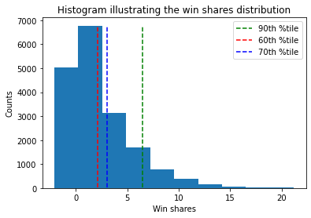

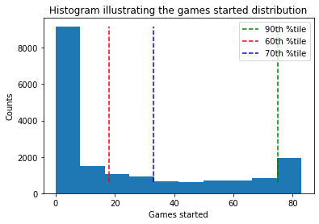

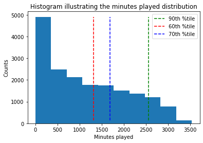

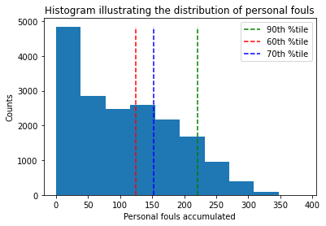

```python
plt.figure()
x, _, _= plt.hist(EDA_seasons_data['WS']) # plot distribution of all win shares for all player seasons
# plot vertical dashed lines for each of the threshold values and label them
plt.vlines(np.sort(EDA_seasons_data['WS'])[top_ten_thres], np.min(x), np.max(x), label = '90th %tile', linestyles = 'dashed', color = 'green')
plt.vlines(np.sort(EDA_seasons_data['WS'])[middle_ten_thres_lo], np.min(x), np.max(x), label = '60th %tile', linestyles = 'dashed', color = 'red')
plt.vlines(np.sort(EDA_seasons_data['WS'])[middle_ten_thres_hi], np.min(x), np.max(x), label = '70th %tile', linestyles = 'dashed', color = 'blue')
plt.xlabel("Win shares")
plt.ylabel("Counts")
plt.legend()
plt.title("Histogram illustrating the win shares distribution")

# repeat for the other statistics of interest
plt.figure()
x, _, _= plt.hist(EDA_seasons_data['GS'])
plt.vlines(np.sort(EDA_seasons_data['GS'])[top_ten_thres], np.min(x), np.max(x), label = '90th %tile', linestyles = 'dashed', color = 'green')
plt.vlines(np.sort(EDA_seasons_data['GS'])[middle_ten_thres_lo], np.min(x), np.max(x), label = '60th %tile', linestyles = 'dashed', color = 'red')
plt.vlines(np.sort(EDA_seasons_data['GS'])[middle_ten_thres_hi], np.min(x), np.max(x), label = '70th %tile', linestyles = 'dashed', color = 'blue')
plt.xlabel("Games started")
plt.ylabel("Counts")
plt.legend()
plt.title("Histogram illustrating the games started distribution")

plt.figure()
x, _, _= plt.hist(EDA_seasons_data['MP'])
plt.vlines(np.sort(EDA_seasons_data['MP'])[top_ten_thres], np.min(x), np.max(x), label = '90th %tile', linestyles = 'dashed', color = 'green')
plt.vlines(np.sort(EDA_seasons_data['MP'])[middle_ten_thres_lo], np.min(x), np.max(x), label = '60th %tile', linestyles = 'dashed', color = 'red')
plt.vlines(np.sort(EDA_seasons_data['MP'])[middle_ten_thres_hi], np.min(x), np.max(x), label = '70th %tile', linestyles = 'dashed', color = 'blue')
plt.xlabel("Minutes played")
plt.ylabel("Counts")
plt.legend()
plt.title("Histogram illustrating the minutes played distribution")

plt.figure()
x, _, _= plt.hist(EDA_seasons_data['PF'])
plt.vlines(np.sort(EDA_seasons_data['PF'])[top_ten_thres], np.min(x), np.max(x), label = '90th %tile', linestyles = 'dashed', color = 'green')
plt.vlines(np.sort(EDA_seasons_data['PF'])[middle_ten_thres_lo], np.min(x), np.max(x), label = '60th %tile', linestyles = 'dashed', color = 'red')
plt.vlines(np.sort(EDA_seasons_data['PF'])[middle_ten_thres_hi], np.min(x), np.max(x), label = '70th %tile', linestyles = 'dashed', color = 'blue')
plt.xlabel("Personal fouls accumulated")
plt.ylabel("Counts")
plt.legend()
plt.title("Histogram illustrating the distribution of personal fouls")

plt.show()
```

The thresholds seem plausible as (by manual inspection) archetypal role players appear to always have around a maximum of 5 win shares, while elite players tend to have win shares above 8 or 9. Win shares above 10 generally qualify as historic seasons.

Thus, to distinguish between star and role players, which from now on we will designate as either or "star" or "support", we will use the 90 percentile threshold as a lower bound for stars, and the 60th and 70th percentiles as the lower and upper bounds for supporting players.

The choice to explore the win shares (`WS`), games started (`GS`), minutes played (`MP`), and personal fouls (`PF`) statistics helps to set up our hypothesis testing, which is explained in the next section. We want to test whether star and supporting playe types differ in their body type variation over time. **Win shares and games started are strong measures of star players, while minutes played and personal fouls can serve as controls - we don't expect those statistics to separate between the two player classes as star and support players should accumulate comparable number of minutes played and fouls over a given season.** There should be less - or only around a baseline level of - correlation between the BMI variance of the players separated by minutes or fouls.

Next, we will use our percentile definitions to track the BMI variation for each year. That is, for each year we will determine all the players who are "stars" (above 90th percentile for all stats) and those who are "supporting" (60-70th percentile in all stats) and take the standard deviation of BMI values of these two groups. This is then plotted over all seasons.

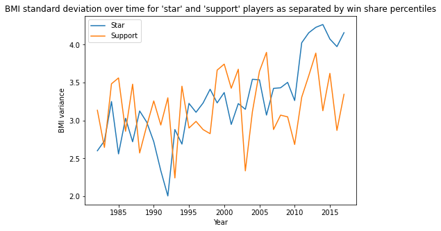

```python
years = pd.unique(EDA_seasons_data['Year'])

BMI_yr_WS_star = []
BMI_yr_WS_supp = []

# we will just annotate this code, as the rest of the cells are the same, just with different stats

for i in range(len(EDA_season_stats)):
    top_ten_thres = int(EDA_season_stats[i].shape[0] * 0.9)
    # find the index (assuming sorted array) that matches the 90th percentile
    mid_ten_thres_lo, mid_ten_thres_hi = int(EDA_season_stats[i].shape[0] * 0.6), int(EDA_season_stats[i].shape[0] * 0.7)
    # find the indices (assuming sorted array) that match the 60th and 70th percentiles
    BMI_yr_WS_star.append(EDA_season_stats[i][EDA_season_stats[i]['WS'] > np.sort(EDA_season_stats[i]['WS'])[top_ten_thres]\
                                   ]['BMI'].std())  # record the std of the player's BMI in the 90th percentile
    intermediate_tab = EDA_season_stats[i][EDA_season_stats[i]['WS'] > np.sort(EDA_season_stats[i]['WS'])[mid_ten_thres_lo]]
    BMI_yr_WS_supp.append(intermediate_tab[intermediate_tab['WS'] < np.sort(EDA_season_stats[i]['WS'])[mid_ten_thres_hi]]\
                          ['BMI'].std())  # record the std of the player's BMI in the 60th to 70th percentile

plt.figure(figsize = (7, 5))
plt.plot(years, BMI_yr_WS_star, label = "Star")
plt.plot(years, BMI_yr_WS_supp, label = "Support")
plt.title("BMI standard deviation over time for 'star' and 'support' players as separated by win share percentiles")
plt.ylabel("BMI variance")
plt.xlabel("Year")
plt.legend()

plt.show()
```

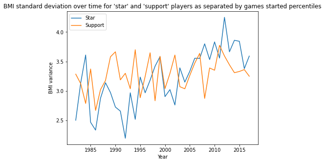

```python
years = pd.unique(EDA_seasons_data['Year'])

BMI_yr_GS_star = []
BMI_yr_GS_supp = []

for i in range(len(EDA_season_stats)):
    top_ten_thres = int(EDA_season_stats[i].shape[0] * 0.9)
    mid_ten_thres_lo, mid_ten_thres_hi = int(EDA_season_stats[i].shape[0] * 0.6), int(EDA_season_stats[i].shape[0] * 0.7)
    BMI_yr_GS_star.append(EDA_season_stats[i][EDA_season_stats[i]['GS'] > np.sort(EDA_season_stats[i]['GS'])[top_ten_thres]\
                                   ]['BMI'].std())
    intermediate_tab = EDA_season_stats[i][EDA_season_stats[i]['GS'] > np.sort(EDA_season_stats[i]['GS'])[mid_ten_thres_lo]]
    BMI_yr_GS_supp.append(intermediate_tab[intermediate_tab['GS'] < np.sort(EDA_season_stats[i]['GS'])[mid_ten_thres_hi]]\
                          ['BMI'].std())

plt.figure(figsize = (7, 5))
plt.plot(years, BMI_yr_GS_star, label = "Star")
plt.plot(years, BMI_yr_GS_supp, label = "Support")
plt.title("BMI standard deviation over time for 'star' and 'support' players as separated by games started percentiles")
plt.ylabel("BMI variance")
plt.xlabel("Year")
plt.legend()

plt.show()
```

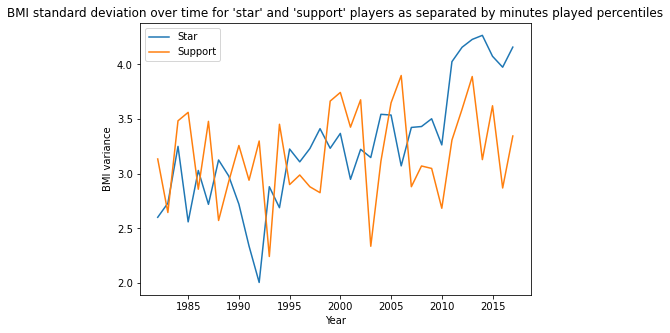

```python
years = pd.unique(EDA_seasons_data['Year'])

BMI_yr_MP_star = []
BMI_yr_MP_supp = []

for i in range(len(EDA_season_stats)):
    top_ten_thres = int(EDA_season_stats[i].shape[0] * 0.9)
    mid_ten_thres_lo, mid_ten_thres_hi = int(EDA_season_stats[i].shape[0] * 0.6), int(EDA_season_stats[i].shape[0] * 0.7)
    BMI_yr_MP_star.append(EDA_season_stats[i][EDA_season_stats[i]['MP'] > np.sort(EDA_season_stats[i]['MP'])[top_ten_thres]\
                                   ]['BMI'].std())
    intermediate_tab = EDA_season_stats[i][EDA_season_stats[i]['MP'] > np.sort(EDA_season_stats[i]['MP'])[mid_ten_thres_lo]]
    BMI_yr_MP_supp.append(intermediate_tab[intermediate_tab['MP'] < np.sort(EDA_season_stats[i]['MP'])[mid_ten_thres_hi]]\
                          ['BMI'].std())

plt.figure(figsize = (7, 5))
plt.plot(years, BMI_yr_WS_star, label = "Star")
plt.plot(years, BMI_yr_WS_supp, label = "Support")
plt.title("BMI standard deviation over time for 'star' and 'support' players as separated by minutes played percentiles")
plt.ylabel("BMI variance")
plt.xlabel("Year")
plt.legend()

plt.show()
```

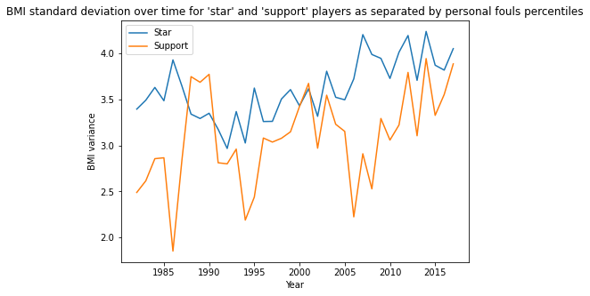

```python
years = pd.unique(EDA_seasons_data['Year'])

BMI_yr_PF_star = []
BMI_yr_PF_supp = []

for i in range(len(EDA_season_stats)):
    top_ten_thres = int(EDA_season_stats[i].shape[0] * 0.9)
    mid_ten_thres_lo, mid_ten_thres_hi = int(EDA_season_stats[i].shape[0] * 0.6), int(EDA_season_stats[i].shape[0] * 0.7)
    BMI_yr_PF_star.append(EDA_season_stats[i][EDA_season_stats[i]['PF'] > np.sort(EDA_season_stats[i]['PF'])[top_ten_thres]\
                                   ]['BMI'].std())
    intermediate_tab = EDA_season_stats[i][EDA_season_stats[i]['PF'] > np.sort(EDA_season_stats[i]['PF'])[mid_ten_thres_lo]]
    BMI_yr_PF_supp.append(intermediate_tab[intermediate_tab['PF'] < np.sort(EDA_season_stats[i]['PF'])[mid_ten_thres_hi]]\
                          ['BMI'].std())

plt.figure(figsize = (7, 5))
plt.plot(years, BMI_yr_PF_star, label = "Star")
plt.plot(years, BMI_yr_PF_supp, label = "Support")
plt.title("BMI standard deviation over time for 'star' and 'support' players as separated by personal fouls percentiles")
plt.ylabel("BMI variance")
plt.xlabel("Year")
plt.legend()

plt.show()
```

The trends don't look very promising, at least from an exploratory perspective. We would hypothesize that the statistics that accurately distinguish star players would reveal some sort of correlation between body type variation and player roles, if it exists. The need to examine "body type diversity" with BMI variance limits the number of data points, which also makes using machine learning/model fitting more difficult in the next step.

We would hope to see, when separated by games started and win shares statistics, a consistent correlation between star and support BMI standard deviations over time, and very little correlation between players BMI standard deviations when separated by minutes played and personal fouls (these statistics are not expected to correspond with player roles as star and support players play similar amounts of minutes over the course of the season, and commit similar numbers of fouls).

**This is because we hypothesize that whether a player is a star or supporting cast member in the NBA is likely to modulate the type of body needed to fill that role, affecting the BMI variation.**

With that, let's move on to testing our rough hypotheses!

## Hypothesis Testing and Machine Learning

Next we will use machine learning techniques to test some of our hypotheses. The best Python libraries for machine learning applications include [scikit-learn](https://scikit-learn.org/stable/), [Tensorflow](https://www.tensorflow.org/api_docs) , [Keras](https://keras.io/), and [PyTorch](https://pytorch.org/docs/stable/index.html) .

For a quick definition, machine learning essentially leverages computing power to find the best set of parameters for a function we choose to model observed data with. This function is described as 'optimally fit' to the data; this is determined by minimizing some cost function that evaluates how accurately the model predicts the observed data. Some common models/functions used in machine learning include linear regression, multiple linear regression, polynomial regression, and k-means clustering, k-nearest neighbors, and logistic regression - each is used to model a different type of input/output data and/or relationship - check out this [helpful online machine learning course for more information](http://ciml.info/). More complex models with many parameters require more observed data points to accurately model the relationship. That will likely be a problem for this tutorial, as we only have 36 points, one per season from 1982 to 2017. We choose linear regression because of our limited number of data points. In the plots below we will abbreviate 'standard deviations' as 'SD'.

Hypothesis testing is a statistical technique where an investigator sets a null and an alternative hypothesis and sees if the observed data produces results that are significantly different from the null hypothesis, given a chosen level of confidence. If it does, the null hypothesis can be rejected in favor of the alternative. See these resources [here](https://www.khanacademy.org/math/statistics-probability/significance-tests-one-sample) and [here](https://www.statisticshowto.com/probability-and-statistics/hypothesis-testing/) for more information.

In our hypothesis testing section, we will compare the slope of the linear regression line fit to the relationship between star and support BMI standard deviations for each year. The models will essentially use the standard deviation of the star players BMI for a given year to predict the corresponding support players BMI standard deviation for the same year. That means we have 36 data points. If the slope is approximately 1, the BMI standard deviations for star and support players have been relatively equal over time.

We will conduct three hypothesis tests. We choose win shares( `WS`) and personal fouls (`PF`) as the statistics across which we will try to divide the players into star and support groups for each season. As mentioned in the exploratory section, we expect win shares to be a accurate measure of player role, so if player role influences the diversity of body type (BMI SD) we will see a slope significantly different from 1. Meanwhile, we don't expect personal fouls to vary with player role (star and support players accumulate similar amounts of fouls), so we would expect the slope of this regression line to be near 1. Our three tests will be as follows:

**Null Hypothesis 1**: The slope of the linear regression between BMI standard deviations for player groups divided by win shares is 1  
**Alternative Hypothesis**: The slope of the linear regression between BMI standard deviations for player groups divided by win shares is not 1

**Null Hypothesis 2**: The slope of the linear regression between BMI standard deviations for player groups divided by personal fouls is 1  
**Alternative Hypothesis 2**: The slope of the linear regression between BMI standard deviations for player groups divided by personal fouls is not 1

**Null Hypothesis 3**: The difference in slopes for the linear regression between BMI standard deviations for player groups divided by win shares versus personal fouls is 0  
**Alternative Hypothesis 3**: The difference in slopes for the linear regression between BMI standard deviations for player groups divided by win shares versus personal fouls is not 0

The null hypotheses all assume that there are no relationships within or differences between the groupings. To conduct our analyses we will import the sklearn library, specifically its linear_model module, and the math library for easy use of some mathematical operators.

```python
import math
from scipy import optimize
from sklearn import datasets, linear_model
```

```python
# fit regression line for win shares condition
WS_vs_BMI_std = linear_model.LinearRegression()
# fit the BMI standard deviations for star players for each year against that of support player defined by win shares
_ = WS_vs_BMI_std.fit(np.expand_dims(BMI_yr_WS_star, axis = 1), np.expand_dims(BMI_yr_WS_supp, axis = 1))
# make model predictions given BMI standard deviations for star players for each year defined by win shares
predict_BMI_std_supp_WS = WS_vs_BMI_std.predict(np.expand_dims(BMI_yr_WS_star, axis = 1))

# fit regression line for personal fouls condition - same as above otherwise
PF_vs_BMI_std = linear_model.LinearRegression()
_ = PF_vs_BMI_std.fit(np.expand_dims(BMI_yr_PF_star, axis = 1), np.expand_dims(BMI_yr_PF_supp, axis = 1))
predict_BMI_std_supp_PF = PF_vs_BMI_std.predict(np.expand_dims(BMI_yr_PF_star, axis = 1))

print("The regression line for star vs support player BMI SD for groups divided by win shares is: \n y = " \
          + str(WS_vs_BMI_std.coef_[0][0])+ "x + " + str(WS_vs_BMI_std.intercept_[0]))

print("The regression line for star vs support player BMI SD for groups divided by personal fouls is: \n y = " \
          + str(PF_vs_BMI_std.coef_[0][0])+ "x + " + str(PF_vs_BMI_std.intercept_[0]))
```

```
The regression line for star vs support player BMI SD for groups divided by win shares is:
 y = 0.15423936359661017x + 2.6758407745107897
The regression line for star vs support player BMI SD for groups divided by personal fouls is:
 y = 0.363768060301341x + 1.7730858239276204
```

The scatter plots with orange regression lines are plotted below.

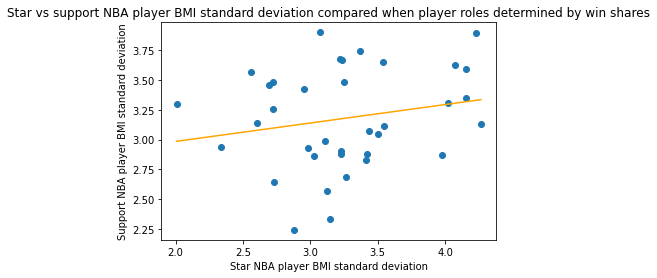

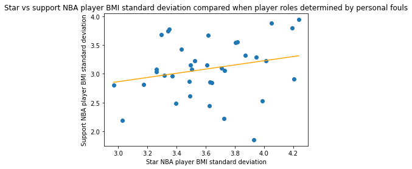

```python
plt.scatter(BMI_yr_WS_star, BMI_yr_WS_supp)

# we have to sort the x and y values by the x value to plot in order
input_output = np.concatenate((np.expand_dims(BMI_yr_WS_star, axis = 1), predict_BMI_std_supp_WS), axis = 1)
sorted_data = input_output[np.argsort(input_output[:, 0])]

plt.plot(sorted_data[:, 0], sorted_data[:, 1], color = 'orange')
plt.title("Star vs support NBA player BMI standard deviation compared when player roles determined by win shares")
plt.xlabel("Star NBA player BMI standard deviation")
plt.ylabel("Support NBA player BMI standard deviation")


plt.figure()
plt.scatter(BMI_yr_PF_star, BMI_yr_PF_supp)

input_output = np.concatenate((np.expand_dims(BMI_yr_PF_star, axis = 1), predict_BMI_std_supp_PF), axis = 1)
sorted_data = input_output[np.argsort(input_output[:, 0])]

plt.plot(sorted_data[:, 0], sorted_data[:, 1], color = 'orange')
plt.title("Star vs support NBA player BMI standard deviation compared when player roles determined by personal fouls")
plt.xlabel("Star NBA player BMI standard deviation")
plt.ylabel("Support NBA player BMI standard deviation")


plt.show()
```

To test if the parameters of the model are significantly different from 1 and each other(do hypothesis testing), we will use a t-test. The null hypothesis for the first two tests are that the parameters of the model are 1, i.e. there is 1-1 correspondence between the BMI standard deviation of the groups of players seperated by win shares (test 1) and personal fouls (test 2).

The alternative hypothesis is that there is a linear relationship between those independent and dependent variables that is significantly different than 1. We will define the alpha value/confidence level to be 0.05, meaning that we will require a t-statistic value that would occur at a less than 5% by chance under the null hypothesis regime in order to reject the null hypothesis in favor of the alternative hypothesis.

We can perform this with t-test with the regression model slopes. Assuming the true slope is 1, calculate the test statistic by taking each each of the slopes from the fitted model, subtract the assumed true/null slope 1, and divide it by the standard error (SE). SE can be computed by taking the square root of mean squared error divided by the total sum of squares for the model's input.

Then compare this test statistic to see if it falls or doesn't fall in the range of the critical values for our chosen confidence level. For an alpha of 0.05 /confidence interval of 95% and n - 1 degrees of freedom (36-1 = 35), the critical values for a two-tailed t-distribution are approximately plus/minus 2.042 (looked up on an online t-distribution table).

```python
residuals = BMI_yr_WS_star - predict_BMI_std_supp_WS # true obs value - predicted value
MSE = np.mean(np.square(residuals)) # mean square of residuals
SE_WS = math.sqrt(MSE/(np.var(BMI_yr_WS_star) * len(BMI_yr_WS_star)))  # calculate standard error for the slope

t_stat_WS = (WS_vs_BMI_std.coef_[0][0] - 1)/SE_WS # calculate the t-stat for win shares condition

print("The t-statistic for the slope of win shares condition is: " + str(t_stat_WS))

# same, but for personal fouls condition
residuals = BMI_yr_PF_star - predict_BMI_std_supp_PF
MSE = np.mean(np.square(residuals))
SE_PF = math.sqrt(MSE/(np.var(BMI_yr_PF_star) * len(BMI_yr_PF_star)))

t_stat_PF = (PF_vs_BMI_std.coef_[0][0] - 1)/SE_PF

print("The t-statistic for the slope of personal fouls condition is: " + str(t_stat_PF))
```

```
The t-statistic for the slope of win shares condition is: -4.966221667742182
The t-statistic for the slope of personal fouls condition is: -1.9551057239290748
```

For the final hypothesis test (3) for determining whether the difference between slopes for the win shares and personal fouls is significant, we can adapt the two-sample t-test for the two regression line slopes. The formula to compute the test-statistic is the difference between the slope divided by the square root of the sum of the standard errors for both slopes (obtained in tests 1 and 2 above)

```python
t_stat_WS_v_PF = (WS_vs_BMI_std.coef_[0][0] - PF_vs_BMI_std.coef_[0][0])/math.sqrt(SE_WS + SE_PF)

print("The t-statistic comparing slopes between conditions is: " + str(t_stat_WS_v_PF))
```

```
The t-statistic comparing slopes between conditions is: -0.2975937563835558
```

Without calculating the explicit p-value, we can compare the critical values (+/- 2.042). If the t-statistic exceeds these critical values in either direction, the trend is significant. The results are as follows:

We reject the first null hypothesis at our chosen confidence level since the t-statistic is outside the range spanned by the critical values (-4.97 < -2.042), indicating that win shares does significantly separate BMI variation between players.

We fail to reject the second null hypothesis at our chosen confidence level since the t-statistic is within the range spanned by the critical values (-1.95 > -2.042), indicating that personal fouls do not significantly separate BMI variation between players.

We fail to reject the third null hypothesis at our chosen confidence level since the t-statistic is well within the range spanned by the critical values (-0.298 > -2.042), indicating that win shares does not do a significantly better job than personal fouls at separating BMI variation between players.

## Conclusions

Our results suggest that body type diversity in the NBA oscillates over time, with the league as a whole becoming more homogeneous and more diverse in terms of body type in a periodic fashion. This trend may depend on the player's role or impact on their team (significant results with win shares only), but this requires more analyses to confirm.

Our results are hampered by the limited number of data points (only 36 seasons) because of our choice to measure the variance/standard deviation of the BMI data. However this metric was the best measure for the question we were interested in. Our hypothesis testing was also limited because we were really testing two conditions in one: whether win shares and personal fouls are good separators of player groups and do those player groups' BMI variation differ significantly. We also made a simplifying assumption about the percentile thresholds. These simplifying assumptions need to be more thoroughly justified thorugh additional quantitative analyses.

Ultimately though, our findings suggest that timing and the current distribution of body types in the NBA influences whether a given player will fulfill a need in the league and be drafted/signed. Understanding the dynamiclandscape of the NBA can be incredibly helpful for athletes who aren't as physically gifted as stars, but have unique physical tools that can be useful for teams, depending on the league/teams' current composition. Depending on the state and stage the NBA is in, maybe that player could be just the right fit for some teams. In many ways, it echoes the deep insights obtained from [Michael Lewis' Moneyball](https://www.amazon.com/Moneyball-Art-Winning-Unfair-Game/dp/0393324818).

Thanks for reading this tutorial, and we hoped it has inspired you to try working through the full data science pipeline for some topic that interests you and you want to learn more about! **[Here is the repo with the source code notebook for this tutorial.](https://github.com/echeng6/DSTutorialNBA)**

-*Ethan Cheng*